# PML_week4

Hemant

25/10/2021

## Project Overview

Using devices such as Jawbone Up, Nike FuelBand, and Fitbit it is now possible to collect a large amount of data about personal activity relatively inexpensively. These type of devices are part of the quantified self movement – a group of enthusiasts who take measurements about themselves regularly to improve their health, to find patterns in their behavior, or because they are tech geeks. One thing that people regularly do is quantify how much of a particular activity they do, but they rarely quantify how well they do it. The goal of your project is to predict the manner in which they did the exercise. This is the “classe” variable in the training set.

We have the following datasets available

The training data for this project are available here: https://d396qusza40orc.cloudfront.net/predmachlearn/pml-training.csv

The test data are available here: https://d396qusza40orc.cloudfront.net/predmachlearn/pml-testing.csv

```r
library(knitr)
knitr::opts_chunk$set(cache=TRUE, cache.lazy = FALSE, echo = TRUE, warning = FALSE, message = FALSE, results = 'hide', dpi = 180, fig.height = 5, fig.width = 8)
library(caret)
library(rpart)
library(randomForest)
library(rpart.plot)
```

### Data Pre-prcessing

We wish to remove the following: 1. NA value observations 1. Any character type columns 1. Any other columns of no importance

```r
training<-read.csv("C:/Users/heman/Downloads/pml-training (1).csv", na.strings = c("NA", "#DIV/0!", ""))
testing<-read.csv("C:/Users/heman/Downloads/pml-testing.csv", na.strings = c("NA", "#DIV/0!", ""))
training<-training[,colSums(is.na(training))==0]
testing<-testing[,colSums(is.na(testing))==0]
training<-training[,-c(1:8)]
testing<-testing[,-c(1:8)]
```

```r
colnames(training)
colnames(testing)
```

### Creating Data Patitions

Creating data partitions to train and validate the models on.

```r
inTrain<-createDataPartition(training$classe, p=0.6, list=FALSE)
train_set<-training[inTrain,]
test_set<-training[-inTrain,]
dim(train_set)
dim(test_set)
colnames(train_set)
colnames(test_set)
```

### Decision Tree

```r
model_DT<-train(classe~., data=train_set, method="rpart")
pred_DT<-predict(model_DT, test_set)
confusionMatrix(factor(pred_DT, levels = c("A","B","C","D","E")), factor(test_set$classe, levels = c("A","B","C","D","E")))
```

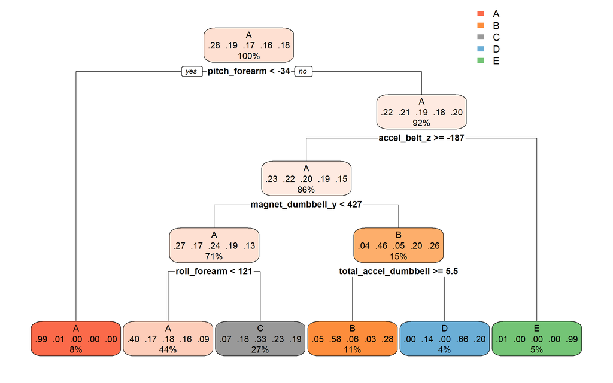

```r
rpart.plot(model_DT$finalModel, roundint = FALSE)
```

### Random Forest Approach

```r
model_RF<-train(classe~., data = train_set, method="rf", ntree=10)
pred_RF<-predict(model_RF, test_set)
pred_RF_CI<-confusionMatrix(factor(pred_RF, levels = c("A","B","C","D","E")), factor(test_set$classe, levels = c("A","B","C","D","E")))
pred_RF_CI
```

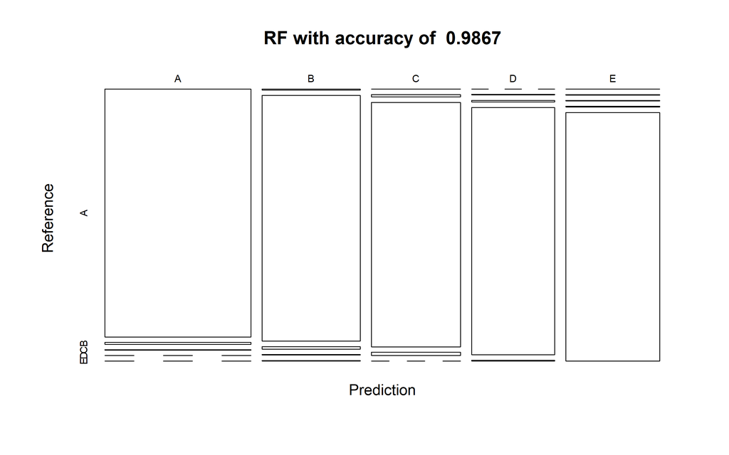

```r
plot(pred_RF_CI$table, col=pred_RF_CI$byClass, main=paste("RF with accuracy of ", round(pred_RF_CI$overall['Accuracy'],4)))
```

### Applying the model to the actual testing data

```r
pred_mainTest<-predict(model_RF, testing)
pred_mainTest
```